# Lab 6

## Problem 3

We now wish to 'zoom in' to the histogram centered about the injected signals that we saw in the above two figures. We would like to inject true signals from 0$\sigma$ to somewhere around 30$\sigma$ and see how the histograms of the observed signals vary.

In order to avoid implicit biasing of signals, we inject linearly spaced signals: 0,1,2,...,999 into our Poisson background centered at 100.

We have 1000 measurements; for each signal strength we a random number generated from a Poisson background centered at 100. That is, for each signal strength we add a random poisson number 1000 times to get a distrubtion about the signal strength.

We then make a 2D histogram, where the x and y axes are the observed signals and the injected signals:

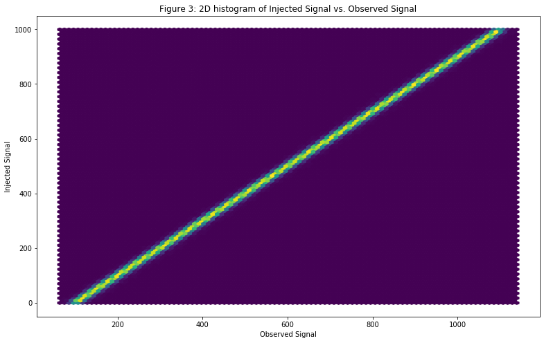

```python
mysize = 1000 #1000 measurments

#below we generate a noise array to be added to the signals
centers = np.full((1,mysize),100)
noise1 = np.random.poisson(lam = centers,size = (mysize,mysize))
noise2 = np.array(noise1)

#below we generated the signals 0,1,2,...,999 (we have 1000 different signal types, linearly spaced)
signal1 = np.linspace(0,999,mysize)
signal = np.array(signal1)

#below we add 1000 different(random) noise values to each signal strength to get a distribution for each strength
obssignal = noise2
for i in range(mysize):
    temp = signal[i]
    obssignal[i] = noise2[i] + temp

scratch, signalmesh = np.meshgrid(signal,signal)

figure()
plt.hexbin(obssignal,signalmesh,bins = 100)
plt.xlabel('Observed Signal')
plt.ylabel('Injected Signal')
plt.title('Figure 3: 2D histogram of Injected Signal vs. Observed Signal')
plt.show()
```

Let us now compare our answer from problem 2 to the histgoram we see above.

Below we display the histogram we get by taking a 'horizontal slice' of our 2D histogram at Injected Signal = 190. Below that we disply the 'zoomed in' histogram of the observed signal from Figure 1.

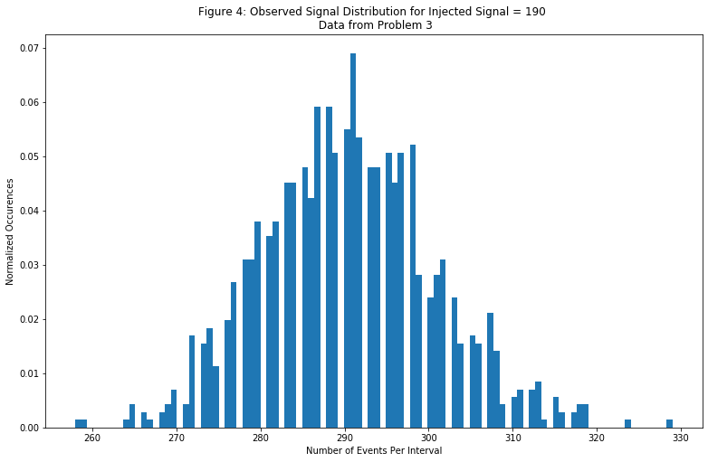

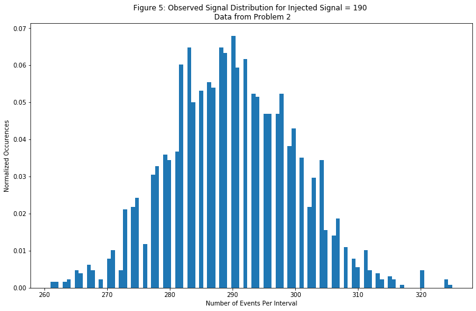

```python
#horizontal slice of 2D histogram at injected signal = 190.
figure()
plt.hist(obssignal[190],bins = 100,density = True)
plt.title('Figure 4: Observed Signal Distribution for Injected Signal = 190 \n Data from Problem 3')
plt.xlabel('Number of Events Per Interval')
plt.ylabel('Normalized Occurences')


data190 = data[indices]
figure()
plt.hist(data190,bins = 100,density = True)
plt.title('Figure 5: Observed Signal Distribution for Injected Signal = 190 \n Data from Problem 2')
plt.xlabel('Number of Events Per Interval')
plt.ylabel('Normalized Occurences')

plt.show()
```

Just to make sure that our above distributions are similar, we plot log plots to observe that the tail behavior is the same:

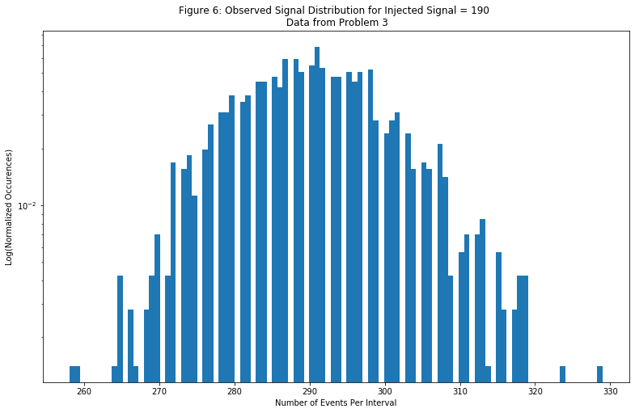

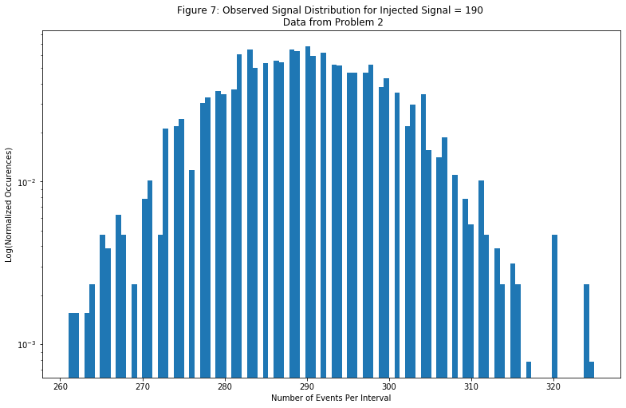

```python
figure()
plt.hist(obssignal[190],bins = 100,density = True)
plt.title('Figure 6: Observed Signal Distribution for Injected Signal = 190 \n Data from Problem 3')
plt.xlabel('Number of Events Per Interval')
plt.ylabel('Log(Normalized Occurences)')
plt.yscale('log')


data190 = data[indices]
figure()
plt.hist(data190,bins = 100,density = True)
plt.title('Figure 7: Observed Signal Distribution for Injected Signal = 190 \n Data from Problem 2')
plt.xlabel('Number of Events Per Interval')
plt.ylabel('Log(Normalized Occurences)')
plt.yscale('log')

plt.show()
```

We now wish to reverse our problem: for a given observed signal what is the histogram of the injected signals that yielded this value?

We perform the calculations below for an observed signal of 600:

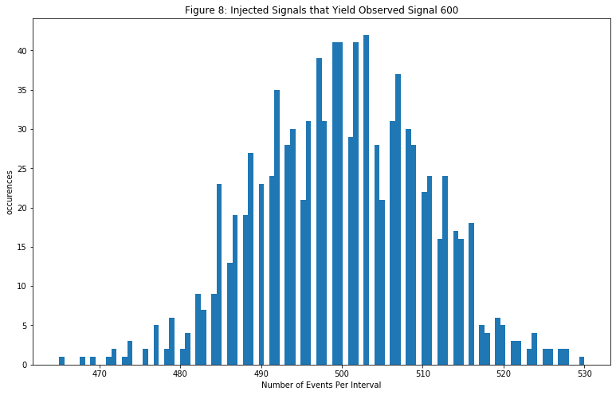

```python
#let observed signal = 600
injectedsignals = np.array([])

for i in range(1000):
    for j in range(1000):
        if abs(obssignal[i][j]-600) < 0.05:
            injectedsignals = np.append(injectedsignals,[i])

figure()
plt.hist(injectedsignals,bins = 100)
plt.title('Figure 8: Injected Signals that Yield Observed Signal 600')
plt.xlabel('Number of Events Per Interval')
plt.ylabel('occurences')
plt.show()
```

The above histogram tells us that the most likely injected signal, given an observed signal of 600, is somewhere around 500 events/interval. It also tells us that there is a nonzero chance of having a true signal of 480 or 520 and getting an observed signal of 600.

However, it is more likely that our true signal is close to the 500 events/interval. Additionally there is no bias: there is no reason why our true signal is more likely to be higher than 500 than it is to be lower than 500.

We would now like to find the exact value of the expected true value, and the error bars associated with the experimental value. Our error bars are associated with $1\sigma$ probability; the right error bar tells you that your true signal will be above the experimental mean and within the given range about 33% of the time, while the left error bar tells you that your true signal will be below the experimental mean and within the given range about 33% of the time.

```python
hist1,bins1 = np.histogram(injectedsignals,bins = 100)

mean1 = injectedsignals.mean()
difference1 = 200
start = 0
for j in bins1:
    difference = abs(j - mean1)
    if difference < difference1:
        difference1 = difference
        start = j

index1 = np.where(bins1 == start)

sum1 = 0
kupper = index1[0][0]
while sum1 < (len(injectedsignals))*0.33:
    sum1 = sum1 + hist1[kupper]
    kupper = kupper+1


sum2 = 0
klower = index1[0][0]
while sum2 < (len(injectedsignals))*0.33:
    sum2 = sum2 + hist1[klower]
    klower = klower - 1

righterror = bins1[kupper] - mean1
lefterror = bins1[klower] - mean1

print('expected true signal = ', mean1)
print('right uncertainty = ',righterror)
print('left uncertainty = ',lefterror)
```

```
expected true signal =  500.0175983436853
right uncertainty =  11.132401656314698
left uncertainty =  -9.667598343685256
```

Though there is a slight difference in left and right uncertainties, we see that they are fairly close and it is still reasonable to say our histogram is not biased.

## Problem 4

We now wish to consider what happens when our true signal is hidden by the background. That is, if our observed signal corresponds to something below 5$\sigma$, what does our histogram of true signals look like?

Below we consider an observed signal of 107 (this corresponds to 0.7$\sigma$ :

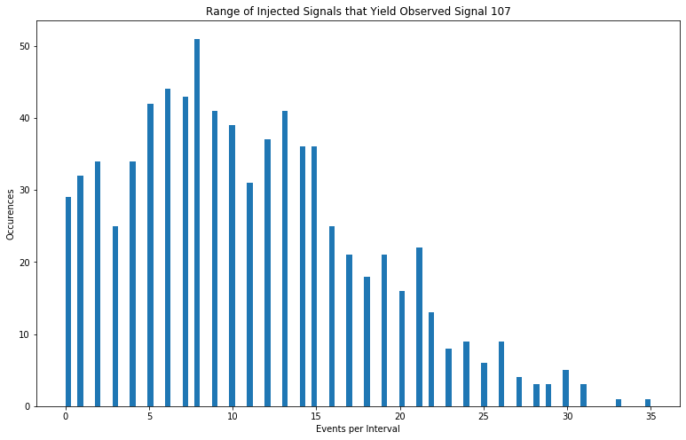

```python
#let observed signal = 107 (0.7 sigma)
injectedsignals07 = np.array([])

for i in range(1000):
    for j in range(1000):
        if abs(obssignal[i][j]-107) < 0.05:
            injectedsignals07 = np.append(injectedsignals07,[i])

figure()
plt.hist(injectedsignals07,bins = 100)
plt.title('Range of Injected Signals that Yield Observed Signal 107')
plt.xlabel('Events per Interval')
plt.ylabel('Occurences')
plt.show()
```

We see that we now have nonzero probability of the true signal being zero. This means that there is a good chance that is a measurment returns 107, that it was produced by the background.

We can still learn something from the above distribution. Let us ask the question:

*if I observe this candidate signal at 107 counts, what is the upper bound on my true signal for 95% of the time?*

We perform the calculation below:

```python
hist2, bins2 = np.histogram(injectedsignals07,bins=100)

sum3 = 0
k = 0
while sum3 < (len(injectedsignals07))*0.95:
    sum3 = sum3 + hist2[k]
    k = k+1

print('95% confidence Interval:', bins2[k])
```

```
95% confidence Interval: 24.15
```

The above calculations tells us:

*If I observe this candidate signal at 107 counts, then the true signal would be less than 24, 95% of the time.*

```python
!jupyter nbconvert --to html Phys434_thalyapaleologu_lab6.ipynb
```

[output not shown]